# Part II - Ford GoBike Trip Data

## Investigation Overview

The primary goal of this investigation is to explore and analyze the FordGoBike dataset to uncover key patterns and insights about user behavior, trip characteristics, and potential relationships between different features. This exploration is aimed at understanding the dynamics of bike-sharing usage, such as the preferences of different user groups, trip durations, and variations based on demographics and user types.

## Dataset Overview

The FordGoBike dataset provides detailed information about individual bike-sharing trips made in the San Francisco Bay Area. Key features of the dataset include:

1. Trip Information:
- duration_sec: The duration of each trip in seconds.
- start_time and end_time: Timestamps for when trips started and ended.
- start_station_id and end_station_id: IDs of the start and end stations for each trip.
2. User Demographics:
- member_birth_year: The year of birth of the user.
- member_gender: The gender of the user (Male, Female, or Other).
- user_type: The type of user (Subscriber or Customer).
3. Station Information:
- start_station_latitude and start_station_longitude: Geographic coordinates of the start station.
- end_station_latitude and end_station_longitude: Geographic coordinates of the end station.

```python
# import all packages and set plots to be embedded inline
import numpy as np
import pandas as pd
import matplotlib.pyplot as plt
import seaborn as sns

%matplotlib inline

# suppress warnings from final output
import warnings
warnings.simplefilter("ignore")
```

```python
# load in the dataset into a pandas dataframe
bike_trips_df = pd.read_csv('cleaned_bike_trips.csv')
bike_trips_df.head()
```

|  | Unnamed: 0 | duration_sec | start_time | end_time | start_station_id | start_station_name | start_station_latitude | start_station_longitude | end_station_id | end_station_name | end_station_latitude | end_station_longitude | bike_id | user_type | member_birth_year | member_gender | bike_share_for_all_trip |
| --- | --- | --- | --- | --- | --- | --- | --- | --- | --- | --- | --- | --- | --- | --- | --- | --- | --- |
| 0 | 0 | 52185 | 2019-02-28 17:32:10.145 | 2019-03-01 08:01:55.975 | 21.0 | Montgomery St BART Station (Market St at 2nd St) | 37.789625 | -122.400811 | 13.0 | Commercial St at Montgomery St | 37.794231 | -122.402923 | 4902 | Customer | 1984.0 | Male | No |
| 1 | 2 | 61854 | 2019-02-28 12:13:13.218 | 2019-03-01 05:24:08.146 | 86.0 | Market St at Dolores St | 37.769305 | -122.426826 | 3.0 | Powell St BART Station (Market St at 4th St) | 37.786375 | -122.404904 | 5905 | Customer | 1972.0 | Male | No |
| 2 | 3 | 36490 | 2019-02-28 17:54:26.010 | 2019-03-01 04:02:36.842 | 375.0 | Grove St at Masonic Ave | 37.774836 | -122.446546 | 70.0 | Central Ave at Fell St | 37.773311 | -122.444293 | 6638 | Subscriber | 1989.0 | Other | No |
| 3 | 4 | 1585 | 2019-02-28 23:54:18.549 | 2019-03-01 00:20:44.074 | 7.0 | Frank H Ogawa Plaza | 37.804562 | -122.271738 | 222.0 | 10th Ave at E 15th St | 37.792714 | -122.248780 | 4898 | Subscriber | 1974.0 | Male | Yes |
| 4 | 5 | 1793 | 2019-02-28 23:49:58.632 | 2019-03-01 00:19:51.760 | 93.0 | 4th St at Mission Bay Blvd S | 37.770407 | -122.391198 | 323.0 | Broadway at Kearny | 37.798014 | -122.405950 | 5200 | Subscriber | 1959.0 | Male | No |

## Dataset Overview

The FordGoBike dataset contains detailed information about individual bike trips taken in the San Francisco Bay Area. Each trip includes key attributes such as trip duration, start and end station locations, user type, gender, and birth year. These details provide an opportunity to analyze user behavior and identify usage trends in bike-sharing.

The dataset is well-suited for this investigation because it captures:

1. Temporal data (start and end times) for analyzing patterns over time.
2. Demographic information (gender and birth year) for studying user diversity.
3. Trip-related metrics (duration and station coordinates) for uncovering mobility trends.

## Key Findings and Insights

### Trip Duration Patterns by User Type

> Subscribers tend to have shorter and more consistent trip durations compared to Customers, who exhibit greater variability.

> **Rubric Tip**: Provide at least 3 **polished** visualizations to convey key insights. The total number of visualizations in the slideshow shoould be less than 50% of the number of visualizations in the exploratory analysis. For example, if the exploratory analysis (Part I) has 18 visualizations, the slideshow can have (3 - 8) visualizations.

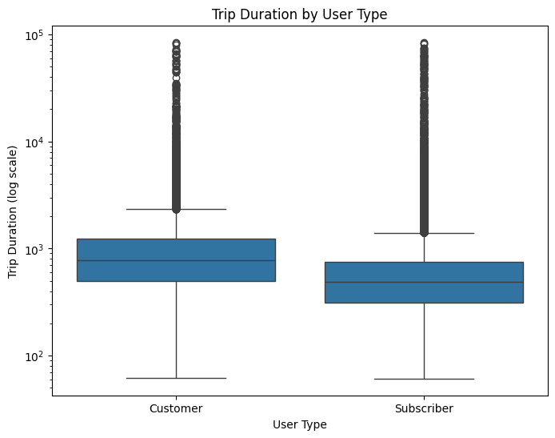

```python
# Box plot for trip duration by user type
plt.figure(figsize=(8, 6))
sns.boxplot(data=bike_trips_df, x='user_type', y='duration_sec')
plt.yscale('log')  # Log scale for better visibility
plt.title('Trip Duration by User Type')
plt.xlabel('User Type')
plt.ylabel('Trip Duration (log scale)')
plt.show()
```

Generated visualization shows shorter trip duration for Subscribers compared to Customers with clear log-scale adjustments for better visibility.